# Bitcoin Authorship Analysis

Comparative Authorship Analysis Methods

Dana Roemling (d.roemling@bham.ac.uk) and Jack Grieve (j.grieve@bham.ac.uk)

2025/06/12

# 1 Introduction

In this markdown we present some of the options for computational authorship analysis in a comparative setting. The markdown will start with some more descriptive techniques and then go into multivariate analyses.

The focus is on some of the candidate authors in the Bitcoin case. As mentioned in class, we are trying to find the best candidate author that could have authored Satoshi Nakamoto’s texts. The main challenges here are that we have both a large number of candidates and possibly an incomplete set of candidates.

The data for this analysis has been gathered by our research group. It is not the full data set, but we want to give you several genres in case you would like to engage with the code here some more. However, we won’t be able to go into detail for all of these.

# 2 `quanteda` and first measures

## 2.1 Libraries I

```r
# Load necessary libraries
library(dplyr)       # For data manipulation
library(ggplot2)     # For plotting graphs
library(stringr)     # For string manipulation

# Change this according to your system & needs
setwd("/Users/dana/Documents/Teaching (recent)/MEDAL")
nakamoto <- '/Users/dana/Documents/Teaching (recent)/MEDAL/Data/Satoshi/forum'
dai <- '/Users/dana/Documents/Teaching (recent)/MEDAL/Data/Dai/forum'

# Install and load the quanteda package for text processing
# install.packages("quanteda")
library(quanteda)
```

## 2.2 Starting with `quanteda`

Quanteda is a library that focuses on text analysis, so it comes in quite handy when we do any kind of authorship analysis. The package further below, which is designed specifically for authorship analysis, build on quanteda, so we will start of here to give you some time (or code) to explore the ‘basics’.

We will start with a comparison between just two sets of forum posts, authored by Nakamoto and Dai. The file paths for those two data sets is defined in the library snippet above.

## 2.3 Average Sentence Length (All Files)

We can automate the process and calculate the ASL for every file in a folder (or just look at the ASL for one file, if we like), and store the results in a dataframe that lets us visualise the results. This way, we can see whether sentence length can tell us something about how the authors typically write their sentences.

```r
# Combined function to calculate average sentence length and
# add author metadata
calculate_avg_sentence_length_with_authors <- function(folder_path) {
  # List all .txt files in the given folder
  file_list <- list.files(folder_path, pattern = "\\.txt$", full.names = TRUE)

  # Initialize empty list to store results
  results <- list()

  # Loop through each file
  for (file in file_list) {
    # Read file contents
    text_data <- readLines(file, warn = FALSE)

    # Create a corpus from the text
    corpus_obj <- corpus(text_data)

    # Reshape corpus into sentences
    sentences <- corpus_reshape(corpus_obj, to = "sentences")

    # Tokenize into words
    tokens_list <- tokens(sentences, what = "word", remove_punct = FALSE)

    # Calculate sentence lengths
    sentence_lengths <- sapply(tokens_list, length)

    # Compute average sentence length
    avg_length <- mean(sentence_lengths)

    # Store result using file name as key
    results[[file]] <- avg_length
  }

  # Convert results into a data frame
  results_df <- data.frame(
    File = names(results),
    Average_Sentence_Length = unlist(results),
    stringsAsFactors = FALSE
  )

  # Reset row names
  rownames(results_df) <- NULL

  # Extract file names without path
  results_df$File <- basename(results_df$File)

  # Derive author names assuming format "Author_filename.txt"
  results_df$Author <- sub("_.*", "", results_df$File)

  return(results_df)
}
```

The chunk above only defined the function, in order to run it we execute the snippet below.

```r
# Run function on both
nakamoto_df <- calculate_avg_sentence_length_with_authors(nakamoto)
dai_df <- calculate_avg_sentence_length_with_authors(dai)

# Combine results
combined_df <- rbind(nakamoto_df, dai_df)
```

Now we can plot the results to see if the two authors, in our case, differ in their average sentence length.

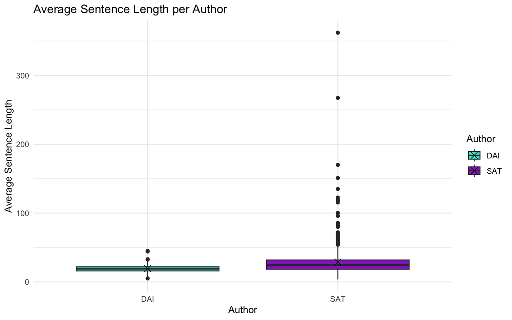

```r
# Define consistent colours
custom_colours <- c("SAT" = "darkorchid",
                   "DAI" = "turquoise")

# Create the boxplot using ggplot2
ggplot(combined_df,
       aes(x = Author,
           y = Average_Sentence_Length,
           fill = Author)
       ) +
  geom_boxplot() +
  stat_summary(fun = mean,
               geom = "point",
               shape = 4,
               size = 3,
               color = "black") +
  labs(
    title = "Average Sentence Length per Author",
    x = "Author",
    y = "Average Sentence Length"
  ) +
  theme_minimal() +
  scale_fill_manual(values = custom_colours)
```

## 2.4 Ideas for Further Work

You could also calculate similar statistics for, for example, average word length or the type-token-ratio. Please note that genre and especially text length will influence these statistics.

# 3 Most Frequent Words

Besides the broader statistics from the last section, we might be interested in the most frequent words used by the two authors as it can tell us something about the stylistic choices. We need some more libraries to get this going.

## 3.1 Libraries II

```r
library(tidyverse)  # Collection of packages for data manipulation and visualization
library(tidytext)   # Tools for text mining using tidy data principles
library(tidyr)      # Helps tidy data (e.g., pivoting, separating columns)
library(readr)      # Fast and friendly functions for reading rectangular data
library(scales)     # Functions for scaling axes and formatting labels in plots
```

We already defined our folder paths for the section above, but now we need a list of all the files in the two folders.

```r
# List all .txt files in the folders of interest
SAT_files <- list.files(nakamoto, pattern = "\\.txt$", full.names = TRUE)
DAI_files <- list.files(dai, pattern = "\\.txt$", full.names = TRUE)
```

## 3.2 Preprocessing

I decided to strip punctuation and to lowercase (which are analytical choices you may not agree with!), but I kept apostrophes in words like “isn’t”. Note that I only read in the txt files after I create the preprocessing function so I can apply it.

```r
# Function to read and preprocess a file
read_and_clean <- function(file) {
  text <- read_file(file)
  # Remove punctuation except apostrophes, convert to lowercase
  text_clean <- tolower(text)
  text_clean <- str_replace_all(text_clean, "[^\\w\\s']+", "")  # keep apostrophes
  tibble(filename = basename(file), text = text_clean)
}

# Read all files per author
SAT_texts <- map_dfr(SAT_files, read_and_clean)
DAI_texts <- map_dfr(DAI_files, read_and_clean)
```

### 3.2.1 Matrices

This next bit does all the work, it tokenises and then counts all the words. Note that only words that occur at least once will show up in the matrices. Note also that these are raw frequencies, nothing is normalised in this step.

```r
# Tokenise into words and count per file
tokenise_count <- function(df) {
  df %>%
    unnest_tokens(word, text, token = "words") %>%
    filter(word != "filename") %>%  # Exclude problematic token
    count(filename, word) %>%
    pivot_wider(
      names_from = word,
      values_from = n,
      values_fill = 0
    ) %>%
    arrange(filename)
}

# Create document-term matrices
SAT_matrix <- tokenise_count(SAT_texts)
DAI_matrix <- tokenise_count(DAI_texts)
```

### 3.2.2 Normalisation

You can normalise per text or per author depending on what you are analysing/comparing. Usually:  
Comparing documents/texts? → Normalise per file  
Comparing authors’ styles? → Normalise per author

For the sake of the matrix, we treat each file as a mini-corpus for which we normalise, so we can then see which words occur frequent across texts and are a sign of an author’s style.

Options to normalise per author (all words by that person) would be for example to look at the sum of each word of that author and normalise the overall count. But since I’m after a matrix in this case, let’s normalise per file (to account for the text length).

In this case I also decided to scale per 1,000,000 words to make the numbers a bit easier to appreciate. Change the scale argument in the normalise_matrix function to use a different scale. This defaults to the pmw now.

```r
# Function to normalise each row (i.e., per file)
normalise_matrix <- function(df, scale = 1e6) {
  filenames <- df$filename
  word_counts <- df %>% select(-filename)

  # Total words per file
  row_totals <- rowSums(word_counts)

  # Divide each cell in a row by the total words in that row
  normalised <- sweep(word_counts, 1, row_totals, FUN = "/") * scale

  # Round the results to two decimal places
  normalised <- round(normalised, 2)

  # Add filename column back
  normalised_df <- bind_cols(tibble(filename = filenames), as_tibble(normalised))

  return(normalised_df)
}

# Apply to matrices
SAT_matrix_norm <- normalise_matrix(SAT_matrix, scale = 1e6)
DAI_matrix_norm <- normalise_matrix(DAI_matrix, scale = 1e6)
```

### 3.2.3 Plotting MFW

Now we can also plot again, which might help to understand what we’ve just done or to explain it to others. This bit will just look at the most frequent words per author.

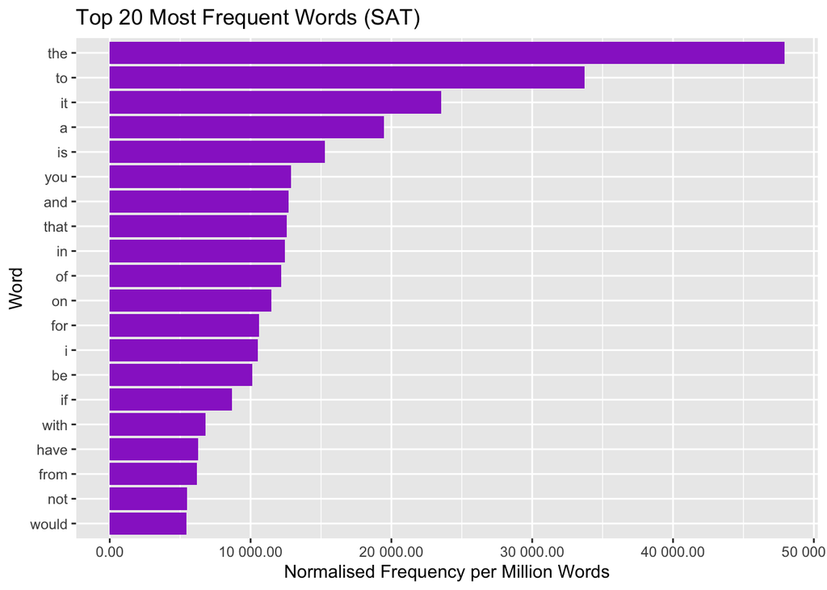

```r
# Get word frequencies for SAT and DAI
SAT_word_frequencies <- SAT_matrix_norm %>%
  select(-filename) %>%
  summarise(across(everything(), mean)) %>%
  unlist()

DAI_word_frequencies <- DAI_matrix_norm %>%
  select(-filename) %>%
  summarise(across(everything(), mean)) %>%
  unlist()

# Create data frames for plotting
SAT_word_df <- tibble(word = names(SAT_word_frequencies), freq = SAT_word_frequencies)
DAI_word_df <- tibble(word = names(DAI_word_frequencies), freq = DAI_word_frequencies)

# Top N (e.g., top 20) words
top_n <- 20
SAT_top_n_words <- SAT_word_df %>%
  arrange(desc(freq)) %>%
  head(top_n)

DAI_top_n_words <- DAI_word_df %>%
  arrange(desc(freq)) %>%
  head(top_n)

# Plot SAT top N words
ggplot(SAT_top_n_words, aes(x = reorder(word, freq), y = freq)) +
  geom_bar(stat = "identity", fill = "darkorchid") +
  coord_flip() +
  scale_y_continuous(labels = label_number(scale = 1, suffix = "", accuracy = 0.01)) +
  labs(title = "Top 20 Most Frequent Words (SAT)", x = "Word", y = "Normalised Frequency per Million Words")
```

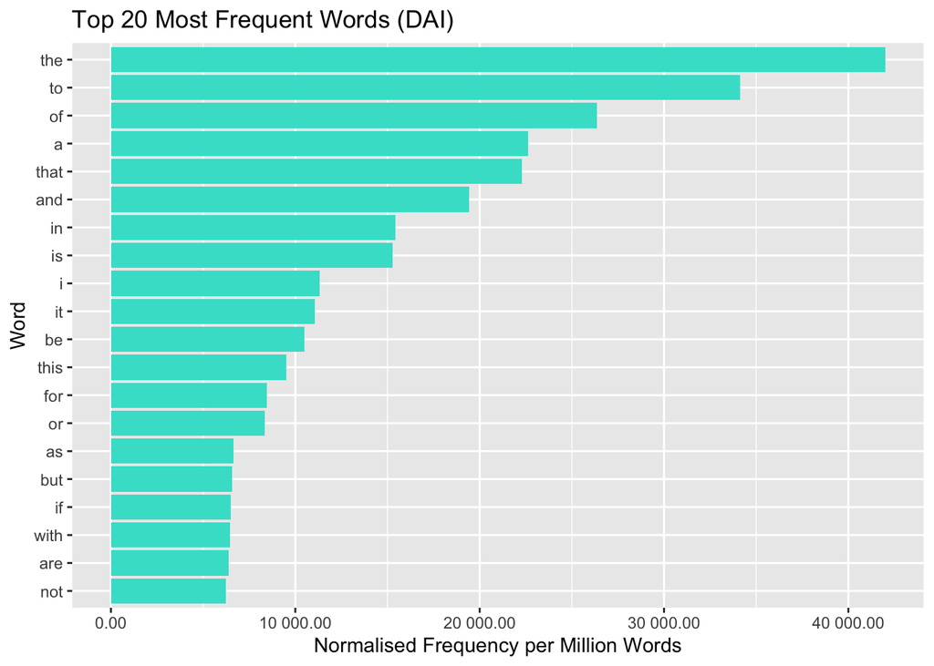

```r
# Plot DAI top N words
ggplot(DAI_top_n_words, aes(x = reorder(word, freq), y = freq)) +
  geom_bar(stat = "identity", fill = "turquoise") +
  coord_flip() +
  scale_y_continuous(labels = label_number(scale = 1, suffix = "", accuracy = 0.01)) +
  labs(title = "Top 20 Most Frequent Words (DAI)", x = "Word", y = "Normalised Frequency per Million Words")
```

### 3.2.4 Plotting single words of interest

If we want to look at a specific word of interest and how it is used by the specific authors (in this case aggreagated across all texts that contain the word in question), this is how to do it:

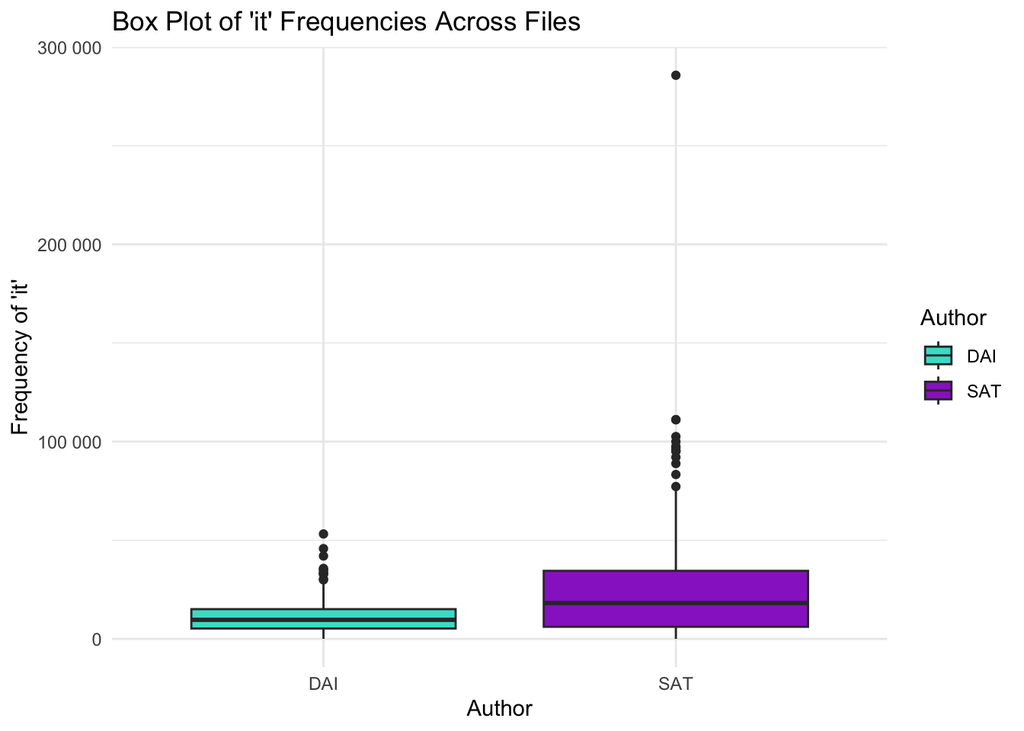

```r
# Filter the normalised data for the word of interest (exact match!)
SAT_single_word <- SAT_matrix_norm %>%
  select(filename, matches("^it$"))

DAI_single_word <- DAI_matrix_norm %>%
  select(filename, matches("^it$"))

# Add a column for the author (to distinguish between SAT and DAI)
SAT_single_word$author <- "SAT"
DAI_single_word$author <- "DAI"

# Combine the data
single_word_data <- bind_rows(SAT_single_word, DAI_single_word)

# Gather the data into a tidy format for plotting
single_word_data_long <- single_word_data %>%
  pivot_longer(cols = -c(filename, author), names_to = "word", values_to = "frequency")

# Define custom colours for each author
custom_colours <- c("SAT" = "darkorchid",
                   "DAI" = "turquoise")

# The actual plot
ggplot(single_word_data_long,
       aes(x = author,
           y = frequency,
           fill = author)) +
  geom_boxplot() +
  labs(title = "Box Plot of 'it' Frequencies Across Files",
       x = "Author",
       y = "Frequency of 'it'",
       fill = "Author") +
  scale_fill_manual(values = custom_colours) +
  scale_y_continuous(labels = label_number()) +
  theme_minimal()
```

# 4 Jaccard Distance

The Jaccard distance is a measure of dissimilarity between two sets. It is defined as one minus the size of the intersection divided by the size of the union of the sets. In other words, it quantifies how different two sets are by comparing the number of shared elements to the total number of unique elements across both sets. The Jaccard distance ranges from 0 to 1, where 0 indicates that the sets are identical, and 1 means they have no elements in common. It is commonly used in text analysis or clustering.

We will continue to just look at the forum posts by Dai and Nakamoto. However, we need some additional libraries for this, but we can use the file paths defined above.

Note that there is also a library called `idiolect`, which is designed for (forensic) stylometry and has an option to use Jaccard distance as well.

## 4.1 Libraries III

```r
library(tm)           # text processing
library(tokenizers)   # tokenisation
library(tidyverse)    # visualisation
library(ggdendro)     # dendrograms
library(umap)         # visualisation / projection
```

## 4.2 Calculating Jaccard Distance

```r
# Function to preprocess text
preprocess <- function(text) {
  text <- iconv(text,
                from = "UTF-8",
                to = "ASCII//TRANSLIT",
                sub = "")  # Convert encoding
  text <- tolower(text)                     # Convert to lowercase
  text <- removePunctuation(text)           # Remove punctuation
  tokens <- unlist(tokenize_words(text))    # Tokenize into words
  return(unique(tokens))                     # Return unique words
}

# Function to compute Jaccard Distance between two texts
jaccard_distance <- function(set1, set2) {
  intersection <- length(intersect(set1,
                                   set2))
  union <- length(union(set1,
                        set2))
  return(1 - (intersection / union))  # Jaccard Distance formula
}

# Function to compute Jaccard Distance matrix for a single folder
compute_jaccard_matrix <- function(folder_path) {
  files <- list.files(folder_path, pattern = "\\.txt$", full.names = TRUE)

  text_sets <- lapply(files, function(file) {
    text <- readLines(file, warn = FALSE)
    return(preprocess(paste(text, collapse = " "))) # Preprocess and tokenize
  })

  num_files <- length(files)
  distance_matrix <- matrix(0, nrow = num_files, ncol = num_files,
                            dimnames = list(basename(files), basename(files)))

  for (i in 1:num_files) {
    for (j in i:num_files) {
      dist <- jaccard_distance(text_sets[[i]], text_sets[[j]])
      distance_matrix[i, j] <- dist
      distance_matrix[j, i] <- dist
    }
  }

  return(distance_matrix)
}

# Function to compute Jaccard Distance matrix between two folders
compute_cross_jaccard_matrix <- function(folder1_path, folder2_path) {
  files1 <- list.files(folder1_path, pattern = "\\.txt$", full.names = TRUE)
  files2 <- list.files(folder2_path, pattern = "\\.txt$", full.names = TRUE)

  text_sets1 <- lapply(files1, function(file) {
    text <- readLines(file, warn = FALSE)
    return(preprocess(paste(text, collapse = " ")))
  })

  text_sets2 <- lapply(files2, function(file) {
    text <- readLines(file, warn = FALSE)
    return(preprocess(paste(text, collapse = " ")))
  })

  num_files1 <- length(files1)
  num_files2 <- length(files2)

  distance_matrix <- matrix(0, nrow = num_files1, ncol = num_files2,
                            dimnames = list(basename(files1), basename(files2)))

  for (i in 1:num_files1) {
    for (j in 1:num_files2) {
      distance_matrix[i, j] <- jaccard_distance(text_sets1[[i]], text_sets2[[j]])
    }
  }

  return(distance_matrix)
}

# Wrapper function to compute all three matrices
compute_jaccard_matrices <- function(folder1_path, folder2_path) {
  cat("Computing Jaccard distances for Folder 1...\n")
  matrix1 <- compute_jaccard_matrix(folder1_path)

  cat("Computing Jaccard distances for Folder 2...\n")
  matrix2 <- compute_jaccard_matrix(folder2_path)

  cat("Computing cross-folder Jaccard distances...\n")
  cross_matrix <- compute_cross_jaccard_matrix(folder1_path, folder2_path)

  return(list(folder1_matrix = matrix1, folder2_matrix = matrix2, cross_matrix = cross_matrix))
}
```

As with the ASL, the snippet above only creates the function we need to do this analysis. The snippet below uses the functions and actually runs the calculation.

```r
results <- compute_jaccard_matrices(nakamoto, dai)
```

```
## Computing Jaccard distances for Folder 1...
## Computing Jaccard distances for Folder 2...
## Computing cross-folder Jaccard distances...
```

```r
cross_matrix <- results$cross_matrix
nakamoto_matrix <- results$folder1_matrix
dai_matrix <- results$folder2_matrix
```

Now with the results stored in the elements defined in the snippet above, we can again visualise the results.

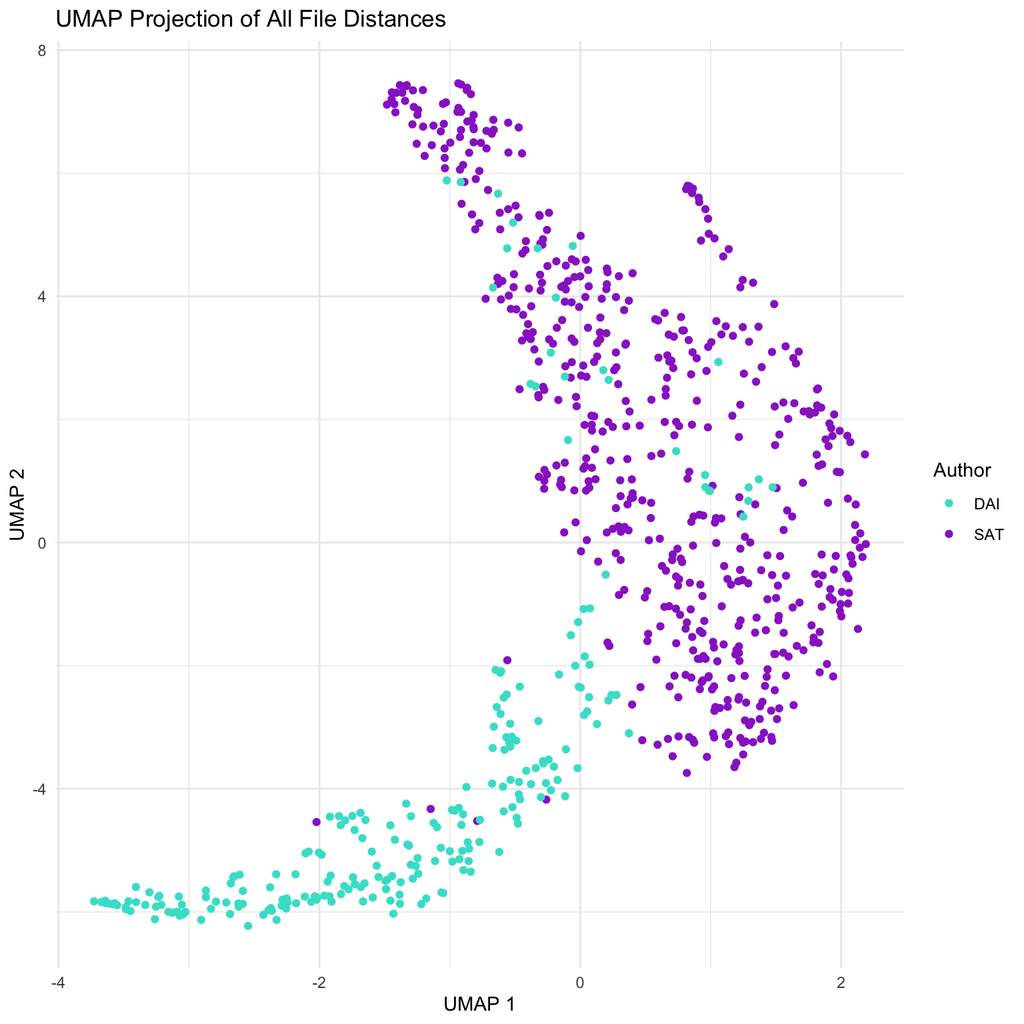

```r
# Create a full distance matrix (773 x 773)
full_matrix <- matrix(NA, nrow = 543 + 230, ncol = 543 + 230)

# Fill in the internal distances for Folder 1 (top-left block)
full_matrix[1:543, 1:543] <- nakamoto_matrix

# Fill in the internal distances for Folder 2 (bottom-right block)
full_matrix[544:773, 544:773] <- dai_matrix

# Fill in the cross-folder distances (top-right block)
full_matrix[1:543, 544:773] <- cross_matrix

# Fill in the symmetric cross-folder distances (bottom-left block)
full_matrix[544:773, 1:543] <- t(cross_matrix)

# Now you have a combined distance matrix

# Apply UMAP to the full distance matrix
umap_result <- umap(full_matrix)

# Create a data frame with UMAP results for visualization
# Get file names for both folders
file_names <- c(basename(list.files(nakamoto, pattern = "\\.txt$", full.names = TRUE)),
                basename(list.files(dai, pattern = "\\.txt$", full.names = TRUE)))

# Folder labels (nakamoto for the first 543, dai for the last 230)
folder_labels <- c(rep("nakamoto", 543), rep("dai", 230))

# Create a data frame to hold the UMAP results
umap_df <- data.frame(UMAP1 = umap_result$layout[, 1],
                      UMAP2 = umap_result$layout[, 2],
                      file = file_names,
                      folder = folder_labels)

# Plot the UMAP results
ggplot(umap_df, aes(x = UMAP1, y = UMAP2, color = folder)) +
  geom_point() +
  labs(title = "UMAP Projection of All File Distances",
       x = "UMAP 1", y = "UMAP 2") +
  theme_minimal() +
  scale_color_manual(values = c("nakamoto" = "darkorchid", "dai" = "turquoise"),
                     labels = c("nakamoto" = "SAT", "dai" = "DAI"),
                     name = "Author")
```

# 5 `stylo`

For the last bit in this markdown, we will have a look at what the library `stylo` can do for us in terms of computational authorship analysis.

If you are on a Mac, you likely need to install X11 as well for it to work. See here for details: https://github.com/computationalstylistics/stylo.

## 5.1 Libraries IV

```r
library(stylo)       # stylometric analysis
```

## 5.2 Data

For this, we usually require larger amounts of data. This is why there is the option here to read in more data. We will load or read in the corpus by author and genre.

First we define a function called loadc(), which we use to collect all the texts from some set of folder paths in our corpus. It takes two arguments: the set of paths and the size of the text sample, and it returns a data frame of meta data and stylo corpus.

```r
loadc <- function(paths, text_l = 500)  # Define function with paths to corpora and a minimum text length
{
  corpus <- list()       # Initialise empty list to hold parsed texts
  df_rows <- list()      # Initialise empty list to hold metadata rows

  for (i in 1:length(paths))  # Loop over each path
  {
    texts <- load.corpus.and.parse(file = "all",  # Initially parse all texts in the directory
                                   paths[i])

    texts <- list.files(paths[i])[lengths(texts) >= text_l]  # Filter out files shorter than text_l

    texts <- load.corpus.and.parse(file = texts,            # Re-parse only texts that meet length requirement
                                   corpus.dir = paths[i],
                                   sample.size=text_l,
                                   sampling="normal.sampling")

    aut  <- sub("\\./Data/(\\w+)/\\w+", "\\1", paths[i])  # Extract author name from file path
    reg  <- sub("\\./Data/\\w+/(\\w+)", "\\1", paths[i])  # Extract register (genre/domain) from path
    cou  <- length(texts)                                 # Count number of valid texts

    df_rows[[i]] <- data.frame(author = aut, register = reg, count=cou)  # Store metadata

    corpus[[i]] <-  texts  # Store parsed texts
  }

  meta <- do.call(rbind, df_rows)  # Combine metadata rows into a single data frame

  alltexts <- unlist(corpus, recursive = FALSE)  # Flatten corpus into a single list of texts
  mfw <- make.frequency.list(alltexts, value = FALSE, relative = FALSE)  # Create frequency list

  return(list(meta = meta, corpus = corpus, mfw = mfw))  # Return list containing metadata, corpus, and frequency list
}
```

Now we can make a list of all the targeted sub corpora and load in that full corpus all at once using the loadc() function.

```r
paths <- c("./Data/Satoshi/paper", "./Data/Satoshi/forum",
           "./Data/Back/paper", "./Data/Back/mail",
           "./Data/Dai/blog", "./Data/Dai/essay", "./Data/Dai/paper",
           "./Data/Dai/mail", "./Data/Dai/forum",
           "./Data/Szabo/blog", "./Data/Szabo/essay", "./Data/Szabo/paper",
           "./Data/Szabo/mail")

data <- loadc(paths, text_l = 200)
```

With the next chunk we can have a look at the corpus we created with that.

```r
data$meta
```

```
##     author register count
## 1  Satoshi    paper    15
## 2  Satoshi    forum    87
## 3     Back    paper   278
## 4     Back     mail     2
## 5      Dai     blog   325
## 6      Dai    essay    25
## 7      Dai    paper    20
## 8      Dai     mail    18
## 9      Dai    forum   388
## 10   Szabo     blog   388
## 11   Szabo    essay   151
## 12   Szabo    paper   347
## 13   Szabo     mail    10
```

```r
#summary(data$corpus)
head(data$mfw,50)
```

```
##  [1] "the"   "of"    "to"    "a"     "and"   "in"    "is"    "that"  "be"
## [10] "for"   "it"    "as"    "this"  "or"    "with"  "are"   "by"    "on"
## [19] "i"     "s"     "can"   "an"    "we"    "not"   "have"  "but"   "which"
## [28] "if"    "from"  "time"  "t"     "more"  "one"   "at"    "other" "they"
## [37] "would" "you"   "will"  "some"  "there" "such"  "than"  "their" "so"
## [46] "about" "these" "was"   "has"   "what"
```

## 5.3 PCA Functions

The first one does the analysis, but allows you to specify which corpora (as indexed by data$meta) and the say how many top most frequent words.

PCA stands for Principal Component Analysis. It is a statistical method used to simplify complex data by reducing the number of variables while retaining most of the important information. Essentially, it transforms the original data into a new set of variables, called principal components, which are uncorrelated and ordered by the amount of variance they explain.

```r
stylo.pca <- function(corpora, types)  # Define function to perform PCA on selected corpora and number of types (words)
{
  texts <- unlist(data$corpus[corpora], recursive = FALSE)  # Extract and flatten selected texts from global 'data$corpus'

  freq <- make.table.of.frequencies(texts,               # Create frequency table from selected texts
                                    data$mfw[1:types],   # Use top 'types' most frequent words from global 'data$mfw'
                                    absent.sensitive = TRUE,  # Include zeroes for absent words
                                    relative = TRUE)          # Use relative frequencies

  pca <- prcomp(freq, scale = TRUE)  # Perform PCA on frequency table, scaling the variables

  scores <- as.data.frame(pca$x)          # Extract PCA scores (coordinates of texts in PC space)
  scores$labels <- names(texts)           # Add text labels (file names or IDs)
  scores$authors <- sub("_.+", "", names(texts))  # Extract author names from labels (assuming format "author_filename")

  return(list(freq = freq, pca = pca, scores = scores))  # Return list of frequency table, PCA object, and scores data frame
}
```

And the second one plots it.

```r
plot.pca <- function(scores, d1, d2, cex = 0.5, cols = NULL) {
  if (!is.null(cols)) {
    col_vector <- cols[scores$authors]  # Use provided color mapping for each author
  } else {
    default_cols <- c("orangered", "forestgreen", "purple2", "goldenrod",   # Default color palette
                      "turquoise3", "darkorange4", "dodgerblue3", "orchid4", "limegreen")

    author_levels <- unique(scores$authors)  # Get unique author names
    author_colors <- setNames(default_cols[seq_along(author_levels)], author_levels)  # Assign colors to authors
    col_vector <- author_colors[scores$authors]  # Map colors to authors in 'scores'
  }

  x <- unlist(scores[d1])  # Extract PCA dimension for x-axis (e.g. PC1)
  y <- unlist(scores[d2])  # Extract PCA dimension for y-axis (e.g. PC2)
  labs <- rownames(scores)  # Get labels for each point (e.g. filenames or IDs)

  plot(x, y, type = "n")  # Initialize empty plot without points
  text(x, y, labels = labs, cex = cex, col = col_vector)  # Add text labels with specified size and color
}
```

This also plots, but with dots instead of file names. Code is the same, minus the labels.

```r
plot.pca.dot <- function(scores, d1, d2, cex = 0.75, cols = NULL) {
  if (!is.null(cols)) {
    col_vector <- cols[scores$authors]
  } else {
    default_cols <- c("orangered", "forestgreen", "purple2", "goldenrod",
                      "turquoise3", "darkorange4", "dodgerblue3", "orchid4", "limegreen")
    author_levels <- unique(scores$authors)
    author_colors <- setNames(default_cols[seq_along(author_levels)], author_levels)
    col_vector <- author_colors[scores$authors]
  }

  x <- unlist(scores[d1])
  y <- unlist(scores[d2])

  plot(x, y, pch = 16, cex = cex, col = col_vector)
}
```

## 5.4 Running the PCA

The code snippets below will actually run the PCA we defined above. In order to keep the colours consistent for each author, let’s define a custom colour palette. Note that there is a default, if you do not wish to define custom colours.

```r
my_colors <- c("SAT" = "darkorchid",
               "DAI" = "turquoise",
               "Back" = "sienna2",
               "Szabo" = "cornflowerblue")
```

Note that `par(mfrow = c(1, 2))` is only there to control the (markdown) layout and you can ignore it for your own work.

### 5.4.1 Back vs. Dai

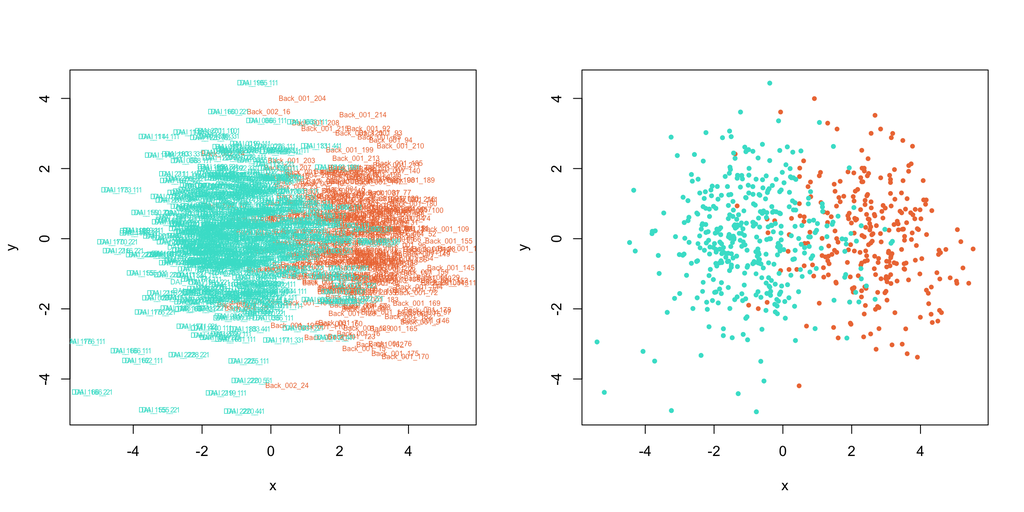

```r
par(mfrow = c(1, 2))
corpora <- c(3, 4, 5, 6, 7, 8, 9)
pca_out <- stylo.pca(corpora, 50)
plot.pca(pca_out$scores, 1, 2, cex=.5, cols = my_colors)

corpora <- c(3, 4, 5, 6, 7, 8, 9)
pca_out <- stylo.pca(corpora, 50)
plot.pca.dot(pca_out$scores, 1, 2, cex=.75, cols = my_colors)
```

### 5.4.2 Back vs. Nakamoto

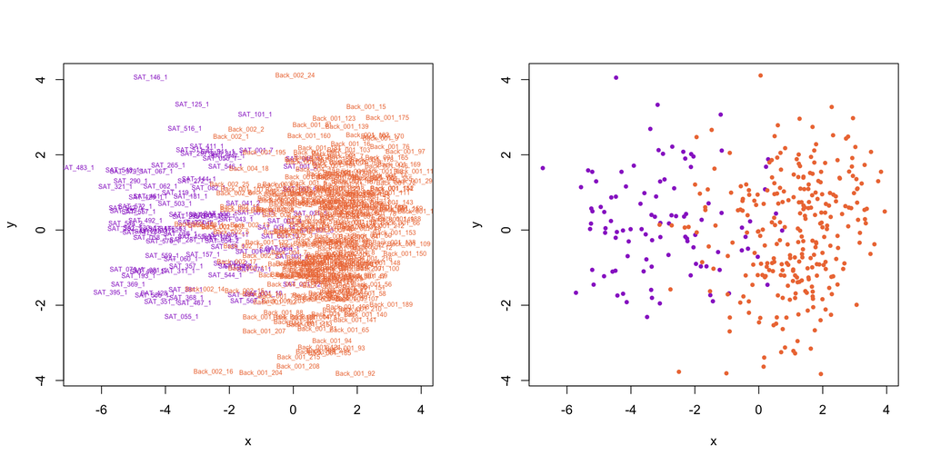

```r
par(mfrow = c(1, 2))
corpora <- c(1, 2, 3, 4)
pca_out <- stylo.pca(corpora, 50)
plot.pca(pca_out$scores, 1, 2, cex=.5, cols = my_colors)

corpora <- c(1, 2, 3, 4)
pca_out <- stylo.pca(corpora, 50)
plot.pca.dot(pca_out$scores, 1, 2, cex=.75, cols = my_colors)
```

### 5.4.3 Back vs. Szabo

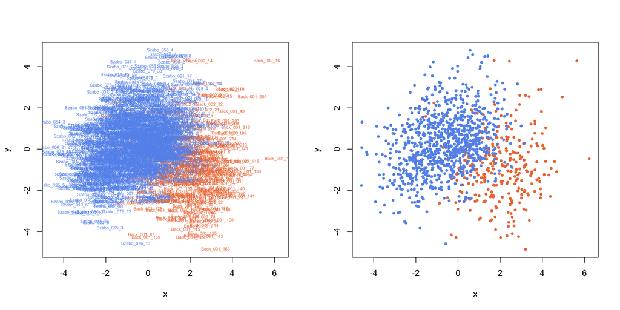

```r
par(mfrow = c(1, 2))
corpora <- c(3, 4, 10, 11, 12, 13)
pca_out <- stylo.pca(corpora, 50)
plot.pca(pca_out$scores, 1, 2, cex=.5, cols = my_colors)

corpora <- c(3, 4, 10, 11, 12, 13)
pca_out <- stylo.pca(corpora, 50)
plot.pca.dot(pca_out$scores, 1, 2, cex=.75, cols = my_colors)
```

### 5.4.4 Dai vs. Nakamoto

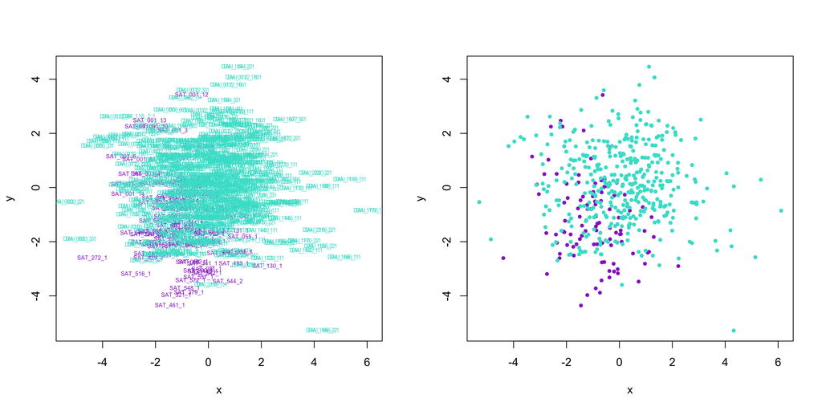

```r
par(mfrow = c(1, 2))
corpora <- c(1, 2, 5, 6, 7, 8, 9)
pca_out <- stylo.pca(corpora, 50)
plot.pca(pca_out$scores, 1, 2, cex=.5, cols = my_colors)

corpora <- c(1, 2, 5, 6, 7, 8, 9)
pca_out <- stylo.pca(corpora, 50)
plot.pca.dot(pca_out$scores, 1, 2, cex=.75, cols = my_colors)
```

### 5.4.5 Dai vs. Szabo

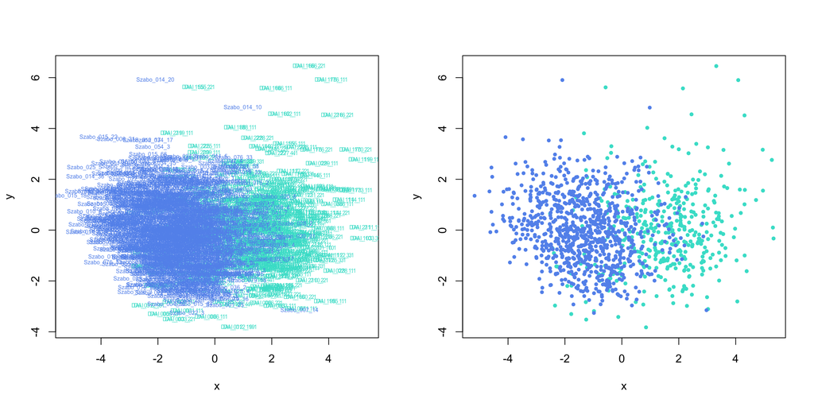

```r
par(mfrow = c(1, 2))
corpora <- c(5, 6, 7, 8, 9, 10, 11, 12, 13)
pca_out <- stylo.pca(corpora, 50)
plot.pca(pca_out$scores, 1, 2, cex=.5, cols = my_colors)

corpora <- c(5, 6, 7, 8, 9, 10, 11, 12, 13)
pca_out <- stylo.pca(corpora, 50)
plot.pca.dot(pca_out$scores, 1, 2, cex=.75, cols = my_colors)
```

### 5.4.6 Nakamoto vs. Szabo

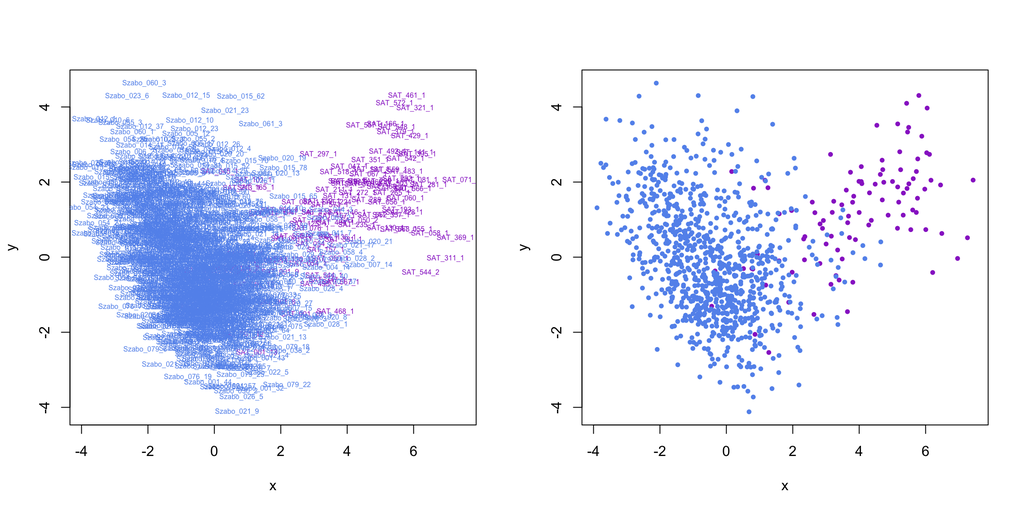

```r
par(mfrow = c(1, 2))
corpora <- c(1, 2, 10, 11, 12, 13)
pca_out <- stylo.pca(corpora, 50)
plot.pca(pca_out$scores, 1, 2, cex=.5, cols = my_colors)

corpora <- c(1, 2, 10, 11, 12, 13)
pca_out <- stylo.pca(corpora, 50)
plot.pca.dot(pca_out$scores, 1, 2, cex=.75, cols = my_colors)
```

### 5.4.7 All Four Authors

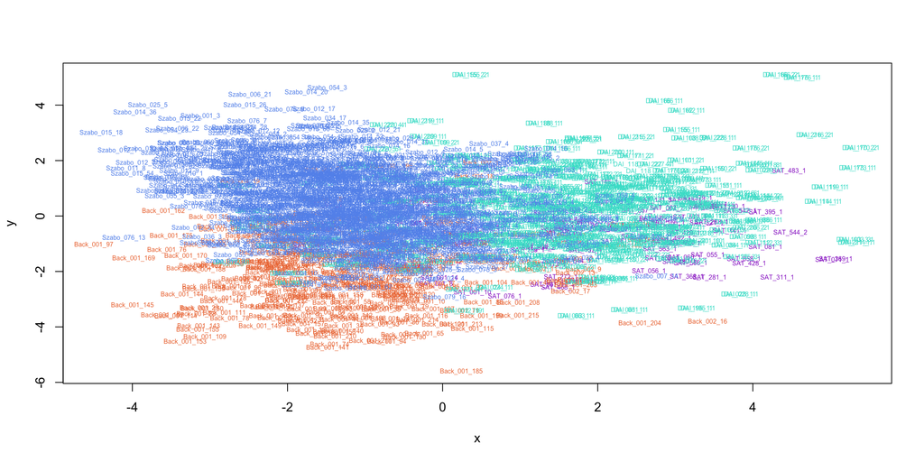

```r
corpora <- c(1, 2, 3, 4, 5, 6, 7, 8, 9, 10, 11, 12, 13)
pca_out <- stylo.pca(corpora, 50)
plot.pca(pca_out$scores, 1, 2, cex=.5, cols = my_colors)
```

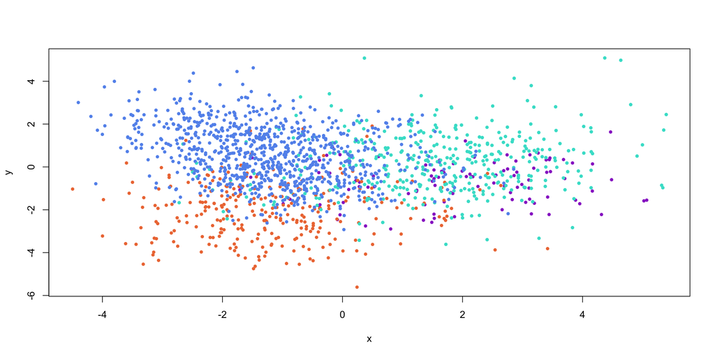

```r
corpora <- c(1, 2, 3, 4, 5, 6, 7, 8, 9, 10, 11, 12, 13)
pca_out <- stylo.pca(corpora, 50)
plot.pca.dot(pca_out$scores, 1, 2, cex=.75, cols = my_colors)
```

### 5.4.8 Authors by themselves

In case we want to investigate outliers within the authors, these plots might help us to see those.

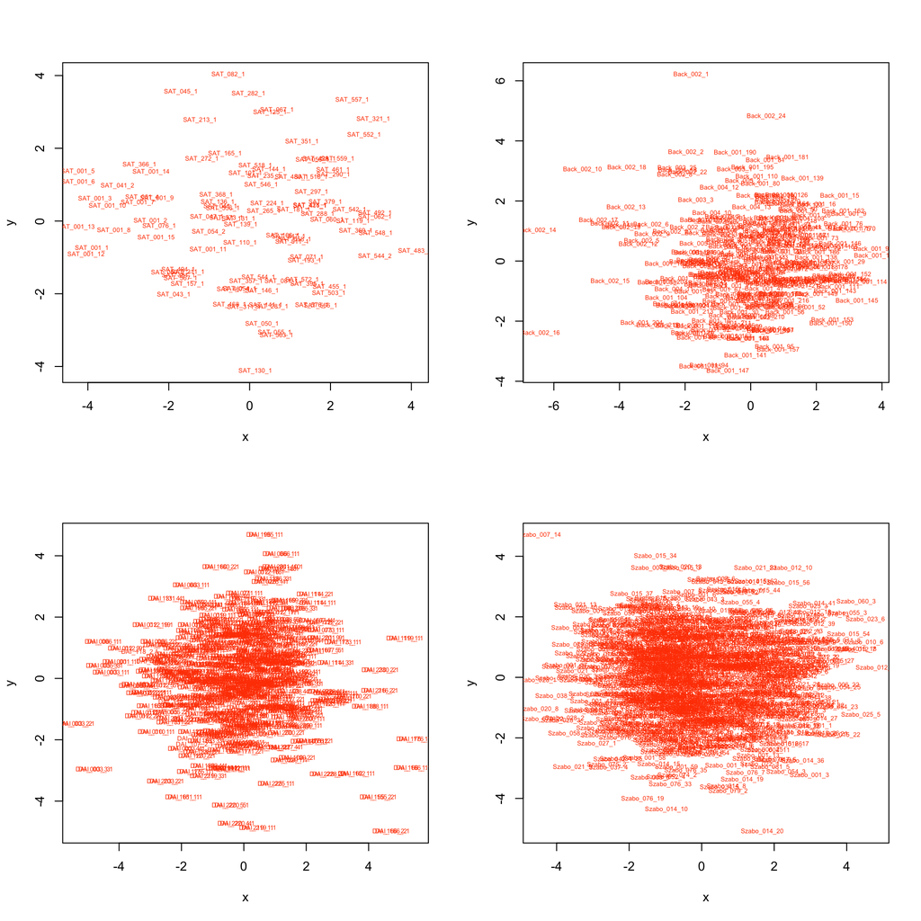

```r
par(mfrow = c(2, 2))
corpora <- c(1, 2)
pca_out <- stylo.pca(corpora, 50)
plot.pca(pca_out$scores, 1, 2, cex=.5)

corpora <- c(3, 4)
pca_out <- stylo.pca(corpora, 50)
plot.pca(pca_out$scores, 1, 2, cex=.5)

corpora <- c(5, 6, 7, 8, 9)
pca_out <- stylo.pca(corpora, 50)
plot.pca(pca_out$scores, 1, 2, cex=.5)

corpora <- c(10, 11, 12 ,13)
pca_out <- stylo.pca(corpora, 50)
plot.pca(pca_out$scores, 1, 2, cex=.5)
```